# STA363_Lab_8

Zishan Shao

2022-11-17

```
##       species          island    bill_length_mm  bill_depth_mm
##  Adelie   :146   Biscoe   :163   Min.   :32.10   Min.   :13.10
##  Chinstrap: 68   Dream    :123   1st Qu.:39.50   1st Qu.:15.60
##  Gentoo   :119   Torgersen: 47   Median :44.50   Median :17.30
##                                  Mean   :43.99   Mean   :17.16
##                                  3rd Qu.:48.60   3rd Qu.:18.70
##                                  Max.   :59.60   Max.   :21.50
##  flipper_length_mm  body_mass_g       sex           year
##  Min.   :172       Min.   :2700   female:165   Min.   :2007
##  1st Qu.:190       1st Qu.:3550   male  :168   1st Qu.:2007
##  Median :197       Median :4050                Median :2008
##  Mean   :201       Mean   :4207                Mean   :2008
##  3rd Qu.:213       3rd Qu.:4775                3rd Qu.:2009
##  Max.   :231       Max.   :6300                Max.   :2009
```

```
## # A tibble: 6 × 8
##   species island    bill_length_mm bill_depth_mm flipper_l…¹ body_…² sex    year
##   <fct>   <fct>              <dbl>         <dbl>       <int>   <int> <fct> <int>
## 1 Adelie  Torgersen           39.1          18.7         181    3750 male   2007
## 2 Adelie  Torgersen           39.5          17.4         186    3800 fema…  2007
## 3 Adelie  Torgersen           40.3          18           195    3250 fema…  2007
## 4 Adelie  Torgersen           36.7          19.3         193    3450 fema…  2007
## 5 Adelie  Torgersen           39.3          20.6         190    3650 male   2007
## 6 Adelie  Torgersen           38.9          17.8         181    3625 fema…  2007
## # … with abbreviated variable names ¹flipper_length_mm, ²body_mass_g
```

```
## # A tibble: 333 × 1
##    island
##    <fct>
##  1 Torgersen
##  2 Torgersen
##  3 Torgersen
##  4 Torgersen
##  5 Torgersen
##  6 Torgersen
##  7 Torgersen
##  8 Torgersen
##  9 Torgersen
## 10 Torgersen
## # … with 323 more rows
```

```
## # A tibble: 333 × 1
##    bill_depth_mm
##            <dbl>
##  1          18.7
##  2          17.4
##  3          18
##  4          19.3
##  5          20.6
##  6          17.8
##  7          19.6
##  8          17.6
##  9          21.2
## 10          21.1
## # … with 323 more rows
```

```
## # A tibble: 333 × 8
##    species island    bill_length_mm bill_depth_mm flipper_…¹ body_…² sex    year
##    <fct>   <fct>              <dbl>         <dbl>      <int>   <int> <fct> <int>
##  1 Adelie  Torgersen           39.1          18.7        181    3750 male   2007
##  2 Adelie  Torgersen           39.5          17.4        186    3800 fema…  2007
##  3 Adelie  Torgersen           40.3          18          195    3250 fema…  2007
##  4 Adelie  Torgersen           36.7          19.3        193    3450 fema…  2007
##  5 Adelie  Torgersen           39.3          20.6        190    3650 male   2007
##  6 Adelie  Torgersen           38.9          17.8        181    3625 fema…  2007
##  7 Adelie  Torgersen           39.2          19.6        195    4675 male   2007
##  8 Adelie  Torgersen           41.1          17.6        182    3200 fema…  2007
##  9 Adelie  Torgersen           38.6          21.2        191    3800 male   2007
## 10 Adelie  Torgersen           34.6          21.1        198    4400 male   2007
## # … with 323 more rows, and abbreviated variable names ¹flipper_length_mm,
## #   ²body_mass_g
```

# Question 1:

*Grow a classification tree for Y= sex using all the available features. Call this tree tree1. Show your tree as your answer to this question. You are welcome to use the standard stopping rules (meaning you do not have to set your own unless you would like to).*

**ANS:**

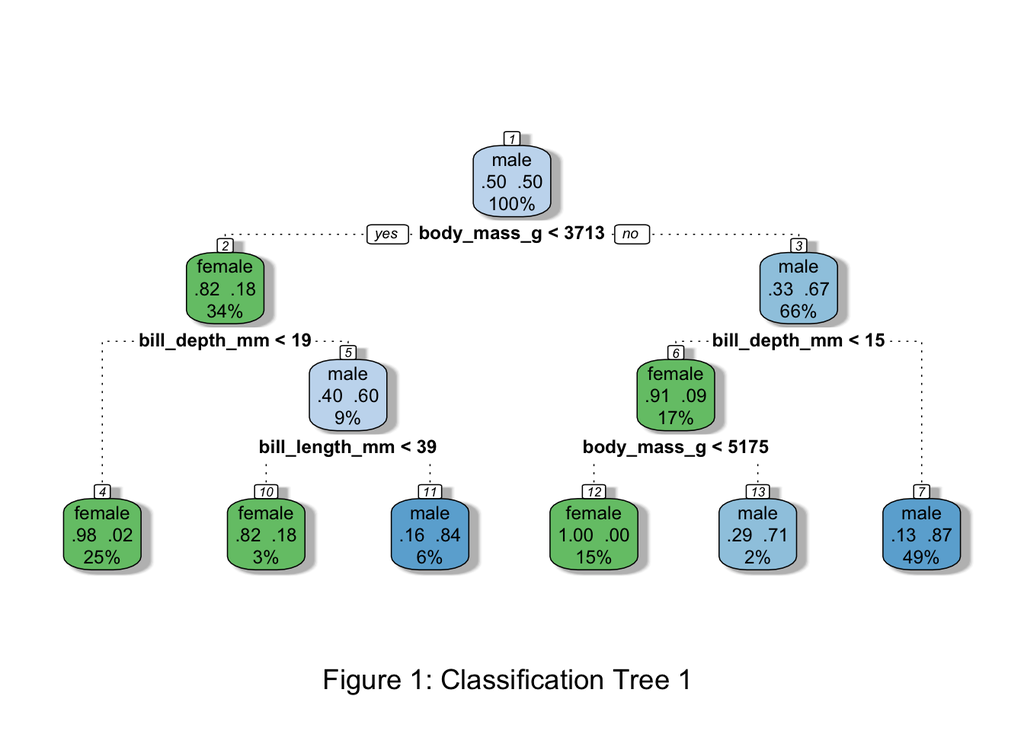

# Question 2:

*What is the Gini Index of the first split of this tree?*

**ANS:** The Gini Index was computed by the Gini Impurity Scores of every leaves. In the first split, it generates two leaves with the first leaf taking 34% of total observations and second leaf taking 66% of total observations. The gini impurity score of leaf 1 is 0.2952, and the gini impurity score of leaf 2 is 0.4422. thus the Gini Index was 0.3922.

$$G(leaf1) = 1 - 0.82^2 - 0.18^2 =
0.2952$$
$$G(leaf2) = 1 - 0.33^2 -
0.67^2 = 0.4422$$
$$Gini \ Index =
0.34 \times 0.2952 + 0.66 \times 0.4422 = 0.3922$$

# Question 3:

# Question 4:

*We can use the code predict(tree1) to get predicted probabilities from our tree. What is the predicted probability of being male and of being female for the 3rd penguin in the data set?*

**ANS:** The probability of being female of 3rd penguin is 0.9759 and being male is 0.02410.

```
##     female       male
## 0.97590361 0.02409639
```

# Question 5:

*We can use the code predict(tree1, type = “class”)to get predicted values of sex for each penguin. What is the predicted sex of the 3rd penguin in the data set? Note: this code chooses the class associated with the highest predicted probability.*

**ANS:** The 3rd penguin was predicted as a female penguin.

```
##      3
## female
## Levels: female male
```

# Question 6:

*Create a confusion matrix for tree1. Hint: You may need to refer back to your logistic regression lab for this.*

**ANS:**

Confusion matrix of Penguins

|  | True Female | True Male |
| --- | --- | --- |
| female | 139 | 4 |
| male | 26 | 164 |

# Question 7:

*What is the sensitivity of your classification tree? Let 0 = female and 1 = male.*

**ANS:** sensitivity(true positive rate) = 164/(4 + 164) = 0.9762 = 97.62%

# Question 8:

*What is the specificity of your classification tree? Let 0 = female and 1 = male.*

**ANS:** specificity(true negative rate) = 139/(26 + 139) = 0.8424 = 84.24%

# Question 9:

*What percent of penguins in the training data are incorrectly classified by your tree? In other words, what is the classification error rate (CER)?*

**ANS:** CER = (26+4)/(26+4+139+164) = 0.0901 = 9.01%

# Question 10:

*What percent of penguins in the training data are correctly classified by your tree? In other words, what is the accuracy?*

**ANS:** Accuracy = 1 - CER = 0.910 = 91.0%

# Question 11:

*Create a single bootstrap sample from the penguins data. Use a random seed of 363663. Once you have your sample, grow a tree on that bootstrap sample. Call this tree tree2. Show the tree as the answer to this question.*

**ANS:**

```
## # A tibble: 333 × 8
##    species island    bill_length_mm bill_depth_mm flipper_…¹ body_…² sex    year
##    <fct>   <fct>              <dbl>         <dbl>      <int>   <int> <fct> <int>
##  1 Gentoo  Biscoe              45.5          13.9        210    4200 fema…  2008
##  2 Adelie  Dream               37.6          19.3        181    3300 fema…  2007
##  3 Adelie  Biscoe              35            17.9        190    3450 fema…  2008
##  4 Gentoo  Biscoe              46.2          14.9        221    5300 male   2008
##  5 Adelie  Torgersen           41.1          18.6        189    3325 male   2009
##  6 Gentoo  Biscoe              51.5          16.3        230    5500 male   2009
##  7 Gentoo  Biscoe              53.4          15.8        219    5500 male   2009
##  8 Gentoo  Biscoe              46.5          14.5        213    4400 fema…  2007
##  9 Adelie  Dream               41.3          20.3        194    3550 male   2008
## 10 Adelie  Dream               37.2          18.1        178    3900 male   2007
## # … with 323 more rows, and abbreviated variable names ¹flipper_length_mm,
## #   ²body_mass_g
```

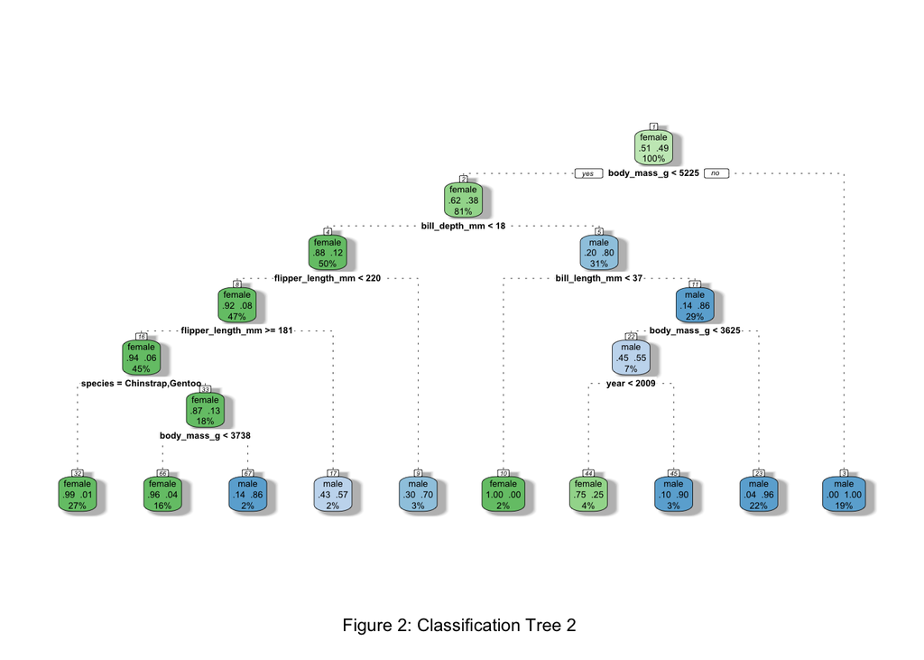

# Question 12:

*Which rows in the penguins data set are OOB for your bootstrap sample?*

**ANS:** OOBs of the bootstrap sample:

```
##   [1]   1   2   4  10  11  12  15  22  24  26  29  30  31  32  35  40  43  44
##  [19]  45  50  54  56  57  58  59  60  61  62  64  67  68  69  72  74  77  78
##  [37]  81  82  83  85  89  90  91  92  94  96 102 105 108 109 113 116 117 118
##  [55] 121 122 124 133 137 139 140 142 144 146 150 153 154 156 162 168 171 172
##  [73] 177 179 187 189 194 201 205 215 219 220 222 223 224 228 233 235 237 241
##  [91] 242 247 248 249 254 255 259 261 262 269 270 271 272 281 282 283 287 294
## [109] 298 300 302 304 305 306 308 313 318 319 321 322 323 324 325 327 330
```

# Question 13:

*Create a confusion matrix for tree2 and show the matrix as part of your answer. Is this the same as the confusion matrix we got from tree1?*

**ANS:**

Confusion matrix of Penguins (Tree 2)

|  | True Female | True Male |
| --- | --- | --- |
| female | 158 | 6 |
| male | 11 | 158 |

# Question 14:

*Create a for loop that grows and plots a bagged classification forest with 3 trees.*

**ANS:**

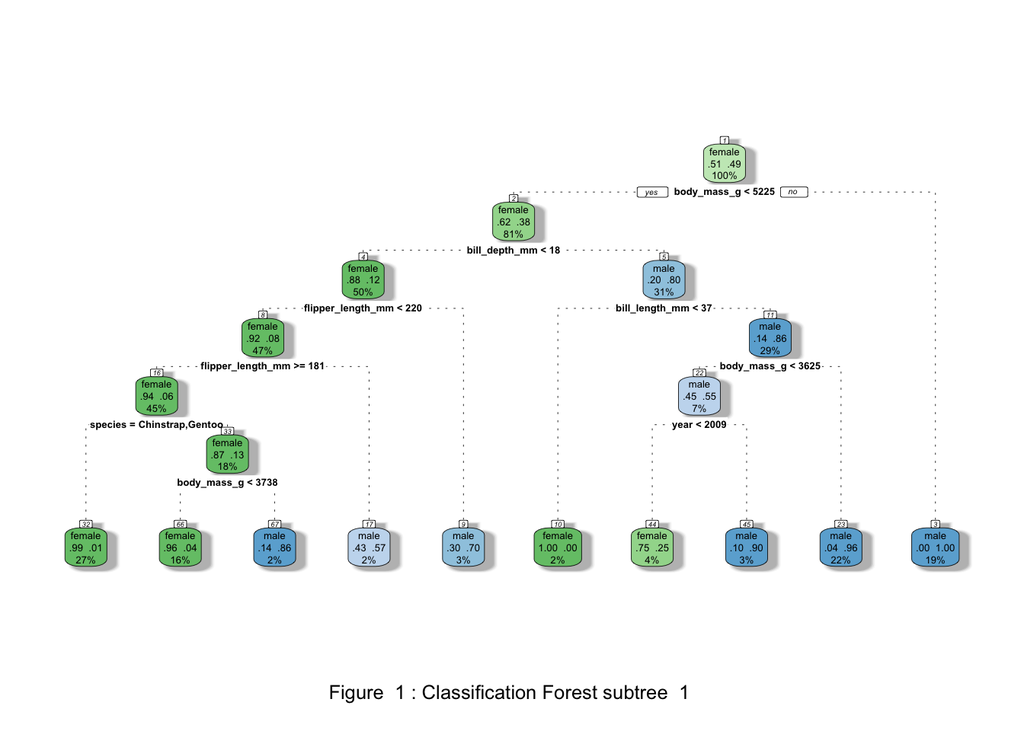

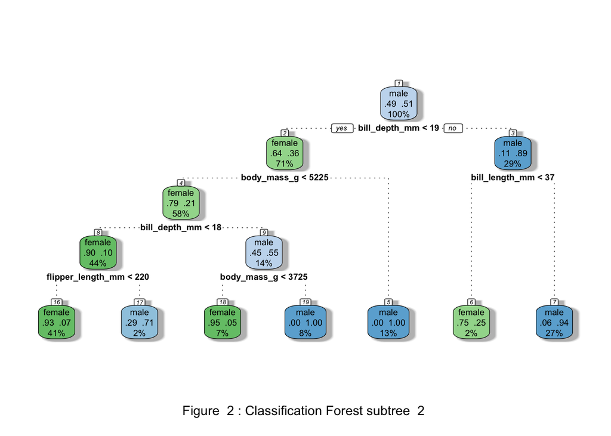

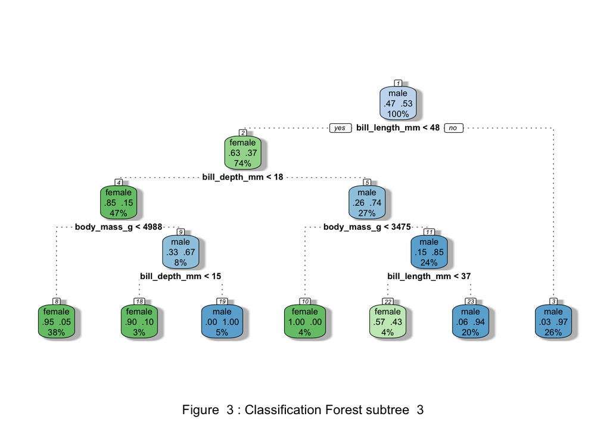

# Question 15:

*Using the package, grow a forest with B=1000 trees and call it forest1. Use the random seed 363663. When you look at the output, you will see OOB estimate of error rate. This is the OOB estimate of the CER. State this CER value as your answer to this question.*

**ANS:**

```
##
## Call:
##  randomForest(formula = sex ~ ., data = penguins, mtry = ncol(penguins) -      1, importance = TRUE, ntree = 1000, compete = FALSE)
##                Type of random forest: classification
##                      Number of trees: 1000
## No. of variables tried at each split: 7
##
##         OOB estimate of  error rate: 8.11%
## Confusion matrix:
##        female male class.error
## female    151   14  0.08484848
## male       13  155  0.07738095
```

# Question 16:

*What is the OOB estimate of the sensitivity?*

# Question 17:

*Which feature is most important in the forest? How can you tell?*

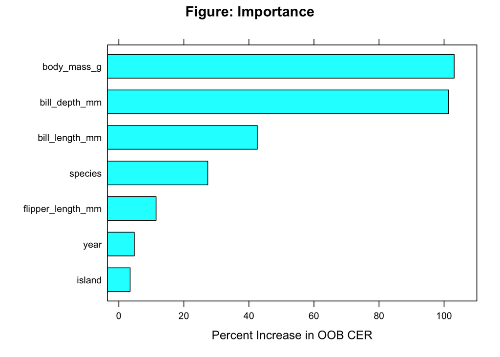

**ANS:** the body_mass_g is the most important feature in the forest, because it leads to largest proportion of increase in OOB after we permuting it.

# Question 18:

*Which feature is least important in the forest? How can you tell?*

**ANS:** The island, because it cause the least percent increase of OOB error rate after we permuting it, indicating that this feature was not a strong explanatory variable.

# Question 19:

*By how much (by what percent) does the OOB CER (remember, this means test CER) get worse if we permute the values of species?*

**ANS:** The OOB CER increases by around 27% after we permute the species. Therefore, the OOB CER get worse by 27%.